# Families

Jens von Bergmann

2017-08-10

The [`dotdensity` R package](https://github.com/mountainMath/dotdensity) provides dot-density functions can be used with any kind of data, but it has been designed with hierarchical geographic data, like census data, in mind.

## Families

```r
#devtools::install_github('mountainmath/dotdensity')
library(dotdensity)
#devtools::install_github('mountainmath/cancensus')
library(cancensus)
# options(cancensus.api_key)='<your API key>'
```

Using the [CensusMapper API tool](https://censusmapper.ca/api/CA16) we select the region and variables we need.

```r
dataset='CA16'
regions=list(CT=c("9330069.01","9330069.02"),CSD=c("5915022","5915803")) #list(CMA="59933")
vectors=c("v_CA16_492","v_CA16_493","v_CA16_497","v_CA16_501")
census_data <- get_census(dataset='CA16', regions=regions, vectors=vectors, level='CT')
```

```
Downloading: 3 kB
Downloading: 3 kB
Downloading: 3 kB
Downloading: 3 kB
Downloading: 3 kB
Downloading: 3 kB
```

Armed with that we load in the geographic data for the dissemination blocks and the census data for the dissemination areas. As a pre-caution the census tract level data in case we are missing dissemmination block level data due to privacy or quality concerns.

```r
data_ct <- get_census(geo_format='sp',labels='short',dataset=dataset, regions=regions, vectors=vectors,level="CT") %>% prep_data
data_da <- get_census(geo_format='sp',labels='short',dataset=dataset, regions=regions, vectors=vectors,level="DA") %>% prep_data
```

[output not shown]

```r
data_db <- get_census(geo_format='sp',labels='short',dataset=dataset, regions=regions, vectors=vectors,level="DB")
```

[output not shown]

## Mapping

```r
# Set the categorie we want to map. Those are the labels except we want to replace the "Total" with the "Other" column
categories=attributes(data_ct)$dot_labels$Detail
colors=c("#0000ff", "#ff0000", "#ffff00", "#00ff00")
scale=25
alpha=0.75
size=0.5
```

All that’s left to do is re-aggregate the data and compute the dot locations and map them.

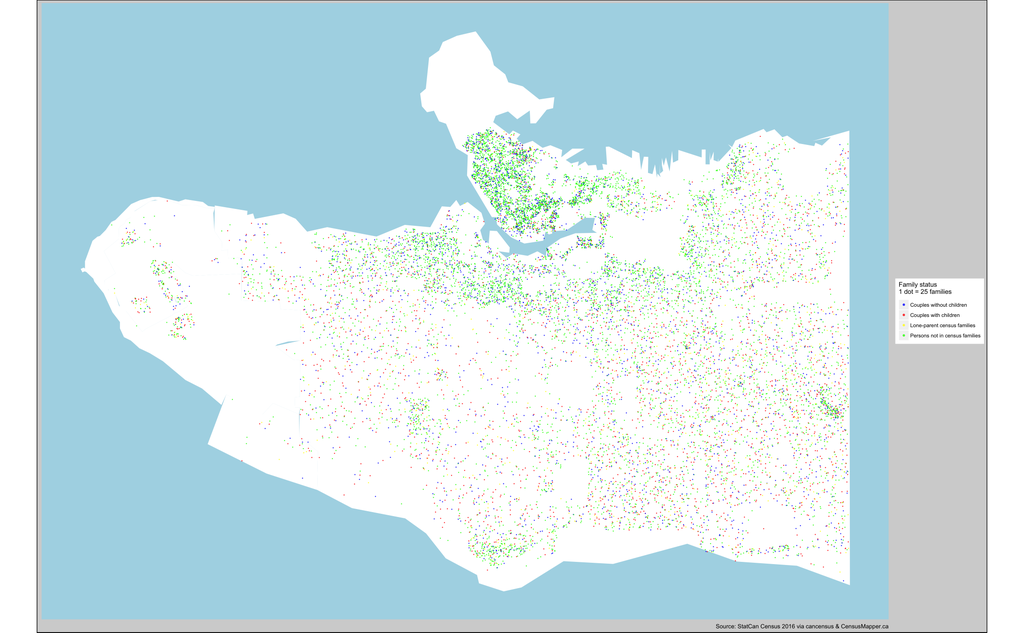

```r
data_da@data <- dot_density.proportional_re_aggregate(data=data_da@data,parent_data=data_ct@data,geo_match=setNames("GeoUID","CT_UID"),categories=categories,base="Population")
data_db@data <- dot_density.proportional_re_aggregate(data=data_db@data,parent_data=data_da@data,geo_match=setNames("GeoUID","DA_UID"),categories=categories,base="Population")
dots.db <- dot_density.compute_dots(geo_data = data_db, categories = categories, scale=scale)
basemap + dot_density.dots_map(dots=dots.db,alpha=alpha,size=size)
```

## Takeaway

By changing a couple of lines of code in the [previous example about languages spoken at home in Vancouver](https://github.com/mountainMath/dotdensity/blob/master/vignettes/languages-example.Rmd) and taking out explanatory steps we could easily build a dot-density map of family status. Using `cancensus`, pulling in the relevant data was a breeze, and the `dotdensity` package did all the relevant dot-density calculations for us.